Assignment 2 data-110

Import Libraries

```python
import pandas as pd
import matplotlib.pyplot as plt
import seaborn as sns
```

Load ALL 3 FILE TYPES

Loading TXT file

```python
df_txt = pd.read_csv("/content/Facebook Friends.txt", encoding='utf-16', sep='\t')

print("TXT File Loaded Successfully")
print("Shape:", df_txt.shape)
print(df_txt.head())
```

```
TXT File Loaded Successfully
Shape: (715, 31)
   Unnamed: 0  Unnamed: 1 Unnamed: 2  Unnamed: 3  Unnamed: 4  Unnamed: 5  \
0           1          57          7          27           5           1
1           2          42        531         241          19           0
2           3          42       1396         423          40           0
3           4          55        394         139          48           0
4           5          30        916         231          78           1

   Unnamed: 6  Unnamed: 7  Unnamed: 8  Friend   ...  Replies  MidWest  Seast  \
0           1           1           0        1  ...       68      NaN    NaN
1           0           0           0        1  ...      234      NaN    NaN
2           1           1           0        1  ...      727      NaN    NaN
3           1           1           1        1  ...      437      NaN    NaN
4           1           1           1        1  ...      372      NaN    NaN

   West  Children  Likes  Edu  Events  USA  Friends
0   NaN       NaN    NaN  NaN     NaN  NaN      NaN
1   NaN       NaN    NaN  NaN     NaN  NaN      NaN
2   NaN       NaN    NaN  NaN     NaN  NaN      NaN
3   NaN       NaN    NaN  NaN     NaN  NaN      NaN
4   NaN       NaN    NaN  NaN     NaN  NaN      NaN

[5 rows x 31 columns]
```

Load CSV File

```python
df_csv = pd.read_csv("/content/Facebook Friends.csv")
print("\nCSV File Loaded Successfully")
print("Shape:", df_csv.shape)
print(df_csv.head())
```

```
CSV File Loaded Successfully
Shape: (715, 3)
  Friend \tAge\tPhotos\t# of Tags\tAlbums\tGender \tEmp\tProfile\tCover\tOrientation\tRelationship\tPosts\tReplies\tMidWest\tSeast\tWest\tChildren\tLikes\tEdu\tEvents\tUSA\tFriends  \
0  1\t57\t7\t27\t5\t1\t1\t1\t0\t1\t1\t1\t0\t0\t0\...
1  2\t42\t531\t241\t19\t0\t0\t0\t0\t1\t1\t5\t1\t0...
2  3\t42\t1396\t423\t40\t0\t1\t1\t0\t1\t1\t186\t3...
3  4\t55\t394\t139\t48\t0\t1\t1\t1\t1\t1\t6\t4\t1...
4  5\t30\t916\t231\t78\t1\t1\t1\t1\t1\t1\t412\t75...

  Unnamed: 1 Unnamed: 2
0        NaN        NaN
1        NaN        NaN
2        NaN        NaN
3        NaN        NaN
4        NaN        NaN
```

Load Excel File

```python
df_excel = pd.read_excel("/content/Facebook Friends.xlsx")
print("\nExcel File Loaded Successfully")
print("Shape:", df_excel.shape)
print(df_excel.head())
```

```
Excel File Loaded Successfully
Shape: (715, 18)
   Sample   Age  Photos  # of Tags  Albums  Gender   Emp  Profile  Cover  \
0        1   57       7         27       5        1    1        1      0
1        2   42     531        241      19        0    0        0      0
2        3   42    1396        423      40        0    1        1      0
3        4   55     394        139      48        0    1        1      1
4        5   30     916        231      78        1    1        1      1

   Orientation  Relationship  Posts  Replies  Children  Likes  Edu  Events  \
0            1             1      1        0         3     21    0       0
1            1             1      5        1         3      9    0       1
2            1             1    186       31         2     43    1       1
3            1             1      6        4         2    187    0       4
4            1             1    412      752         1     34    0       2

   Friends
0       68
1      234
2      727
3      437
4      372
```

Compare All Three Datasets

```python
print("\nTXT shape:", df_txt.shape)
print("CSV shape:", df_csv.shape)
print("Excel shape:", df_excel.shape)

print("\nTXT vs CSV same?:", df_txt.shape == df_csv.shape)
print("CSV vs Excel same?:", df_csv.shape == df_excel.shape)
```

```
TXT shape: (715, 31)
CSV shape: (715, 3)
Excel shape: (715, 18)

TXT vs CSV same?: False
CSV vs Excel same?: False
```

Use Excel Data for the Rest of the Analysis

```python
df = df_excel.copy()
```

Data Examination

```python
print("Column Names:")
print(df.columns)

print("\nTop 5 Rows:")
print(df.head())

print("\nBottom 5 Rows:")
print(df.tail())

print("\nData Types:")
print(df.dtypes)

print("\nMissing Values:")
print(df.isnull().sum())
```

```
Column Names:
Index(['Sample ', 'Age', 'Photos', '# of Tags', 'Albums', 'Gender ', 'Emp',
       'Profile', 'Cover', 'Orientation', 'Relationship', 'Posts', 'Replies',
       'Children', 'Likes', 'Edu', 'Events', 'Friends'],
      dtype='object')

Top 5 Rows:
   Sample   Age  Photos  # of Tags  Albums  Gender   Emp  Profile  Cover  \
0        1   57       7         27       5        1    1        1      0
1        2   42     531        241      19        0    0        0      0
2        3   42    1396        423      40        0    1        1      0
3        4   55     394        139      48        0    1        1      1
4        5   30     916        231      78        1    1        1      1

   Orientation  Relationship  Posts  Replies  Children  Likes  Edu  Events  \
0            1             1      1        0         3     21    0       0
1            1             1      5        1         3      9    0       1
2            1             1    186       31         2     43    1       1
3            1             1      6        4         2    187    0       4
4            1             1    412      752         1     34    0       2

   Friends
0       68
1      234
2      727
3      437
4      372

Bottom 5 Rows:
     Sample   Age  Photos  # of Tags  Albums  Gender   Emp  Profile  Cover  \
710      711   25     499          4       0        0    1        1      1
711      712   22     232        101       4        1    0        1      0
712      713   22     327        329      29        1    1        1      0
713      714   24     219          0       8        1    1        1      1
714      715   19     465          0      22        0    1        1      0

     Orientation  Relationship  Posts  Replies  Children  Likes  Edu  Events  \
710            1             1     16       19         0     49    0      11
711            1             0    698      552         0    223    0       4
712            1             1    543      399         0    520    0       6
```

[output cut: 36 more lines]

```
Albums          0
Gender          0
Emp             0
Profile         0
Cover           0
Orientation     0
Relationship    0
Posts           0
Replies         0
Children        0
Likes           0
Edu             0
Events          0
Friends         0
dtype: int64
```

Descriptive Statistics

```python
print("\nDescriptive Statistics:")
print(df.describe())
```

```
Descriptive Statistics:
          Sample          Age        Photos     # of Tags      Albums  \
count  715.000000  715.000000    715.000000    715.000000  715.000000
mean   358.000000   24.406993    723.914685    458.096503   18.952448
std    206.547008    6.969578   1265.112304    720.835481   22.502860
min      1.000000   13.000000      0.000000      0.000000    0.000000
25%    179.500000   21.000000    124.500000     75.500000    6.000000
50%    358.000000   22.000000    320.000000    250.000000   12.000000
75%    536.500000   25.000000    757.000000    566.500000   22.500000
max    715.000000   81.000000  11995.000000  10460.000000  172.000000

          Gender          Emp     Profile       Cover  Orientation  \
count  715.000000  715.000000  715.000000  715.000000   715.000000
mean     0.541259    0.745455    0.917483    0.507692     0.956643
std      0.517932    0.435910    0.275344    0.500291     0.203801
min      0.000000    0.000000    0.000000    0.000000     0.000000
25%      0.000000    0.000000    1.000000    0.000000     1.000000
50%      1.000000    1.000000    1.000000    1.000000     1.000000
75%      1.000000    1.000000    1.000000    1.000000     1.000000
max      2.000000    1.000000    1.000000    1.000000     1.000000

       Relationship       Posts     Replies    Children        Likes  \
count    715.000000  715.000000  715.000000  715.000000   715.000000
mean       0.492308   37.579021   34.816783    0.211189   144.812587
std        0.500291   90.437795   83.629158    0.651555   261.414781
min        0.000000    0.000000    0.000000    0.000000     0.000000
25%        0.000000    6.000000    5.000000    0.000000    21.000000
50%        0.000000   15.000000   14.000000    0.000000    59.000000
75%        1.000000   29.500000   29.000000    0.000000   145.000000
max        1.000000  794.000000  752.000000    5.000000  2619.000000

              Edu      Events      Friends
count  715.000000  715.000000   715.000000
mean     0.267133    8.853147   695.853147
std      0.442772   24.002672   599.527946
min      0.000000    0.000000     3.000000
25%      0.000000    1.000000   302.000000
50%      0.000000    4.000000   563.000000
75%      1.000000    9.000000   893.500000
max      1.000000  396.000000  4999.000000
```

Data Visualization

Histograms for All Numerical Columns

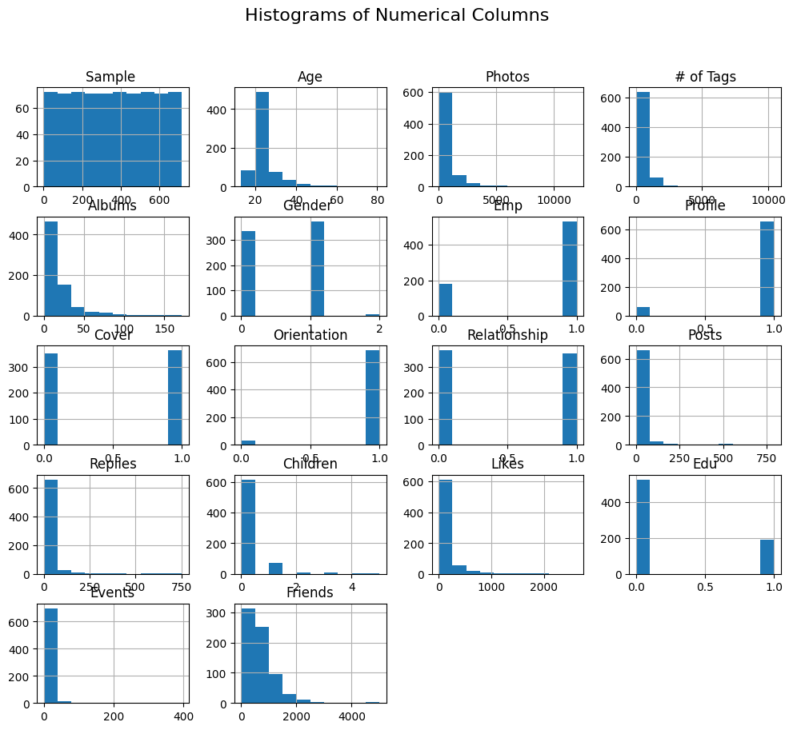

```python
df.hist(figsize=(12, 10))
plt.suptitle("Histograms of Numerical Columns", fontsize=16)
plt.show()
```

Frequency Plots for All Integer/Binary Columns

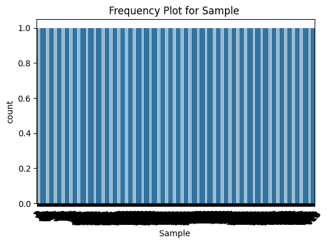

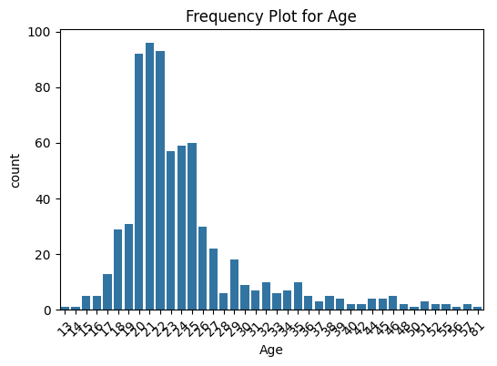

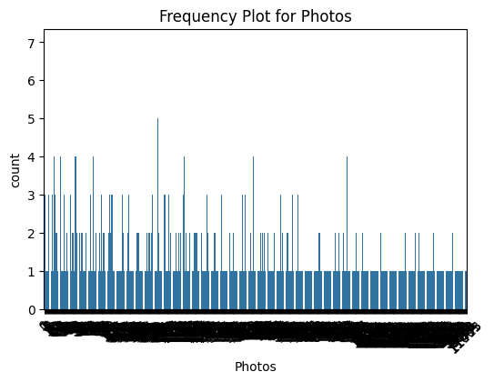

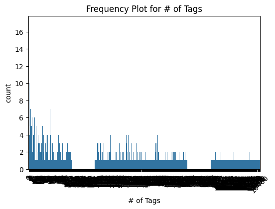

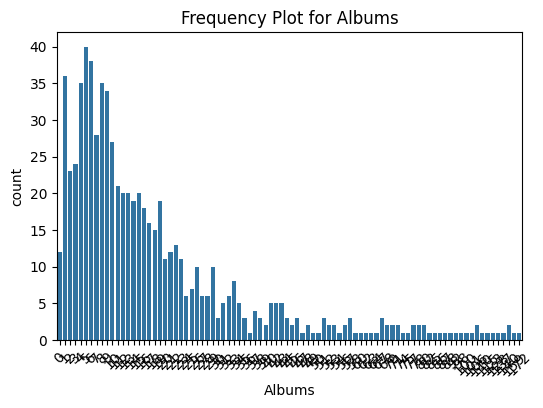

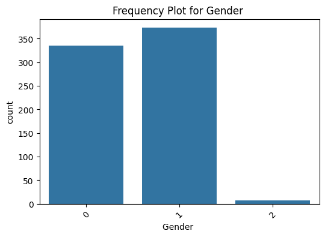

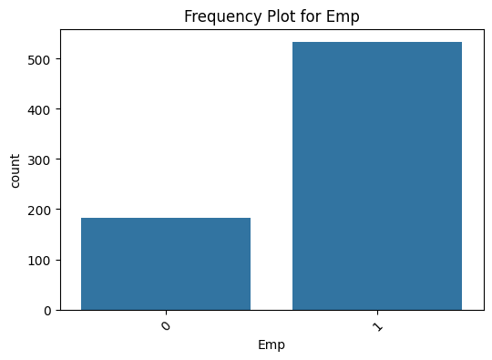

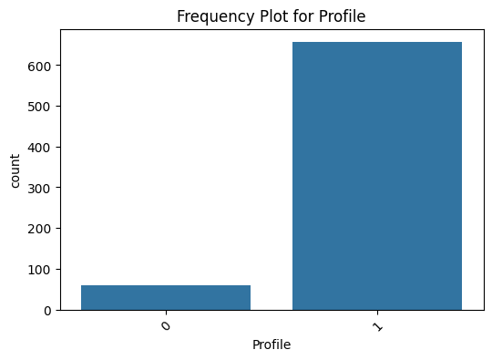

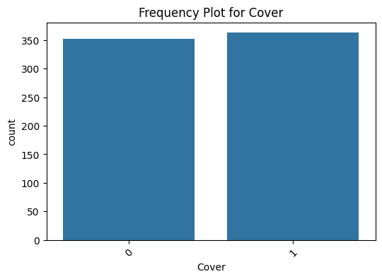

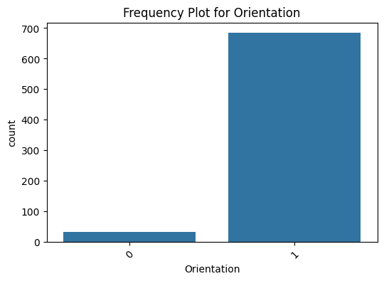

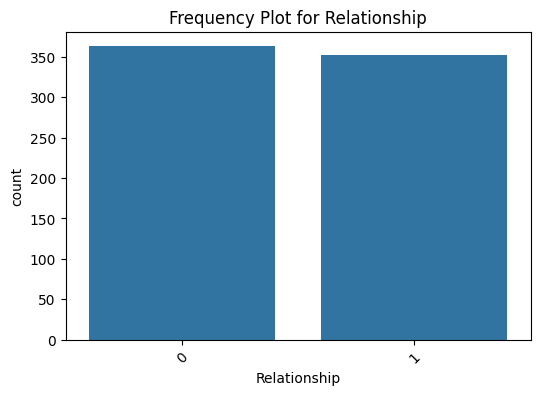

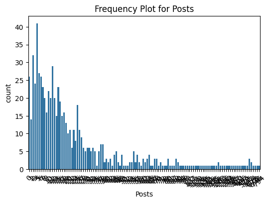

[6 more figures not shown]

```python
categorical_cols = df.select_dtypes(include="int64").columns

for col in categorical_cols:
    plt.figure(figsize=(6, 4))
    sns.countplot(x=df[col])
    plt.title(f"Frequency Plot for {col}")
    plt.xticks(rotation=45)
    plt.show()
```

# Q1: File Differences

q1.Why do the file types (.txt, .csv, .xlsx) differ when loading into Python?

The three files do not contain the same structure or formatting, which causes differences when loading them:

The TXT file loads with 715 rows and 31 columns, showing many extra empty or unnamed columns.

The CSV file loads with 715 rows and only 3 columns, meaning the file uses a different delimiter (likely tab), so it does not split the data correctly.

The Excel file loads cleanly with 715 rows and 18 properly labeled columns.

This shows that file type affects:

How the data is separated (delimiters)

Whether column names are preserved

How many variables are correctly recognized

Conclusion: Yes, the source data format makes a difference. The Excel file is the most complete and properly formatted, which is why it was used for the remaining analysis.

# Q2: Data Examination

q2.What does the data examination show?

The data examination of the Excel file shows:

The dataset contains 18 clean and meaningful columns .

The first and last rows (head and tail) show correctly aligned data with no formatting problems.

All columns are numeric (int64), meaning there are no text or mixed data types.

The dataset contains zero missing values in all columns.

Conclusion: The dataset is complete, consistent, and ready for statistical analysis without needing cleaning or preprocessing.

# Q3: Describe() Interpretation

q3.What does the describe() output show, and how do you interpret it?

The describe() function provides statistical summaries for each numerical column:

count – number of valid values

mean – average

std – standard deviation (variability)

min/max – range

25%, 50%, 75% – quartiles

Key insights:

Age averages around 24, ranging from 13 to 81.

Photos, Tags, Likes, Friends show very high maximum values and large standard deviations, indicating some users are extremely active.

Conclusion: describe() reveals the distribution characteristics and highlights outliers and skewness in activity-related variables.

# Q4: Visualization Insights

q4.What did you learn from the data visualizations?

From the histograms:

Many variables (Photos, Likes, Friends, Tags) show right-skewed distributions, meaning only a few users have extremely high values.

Age distribution peaks between 20–25, indicating more young users.

Binary variables show clear 0/1 patterns.

From the frequency plots:

Some variables have almost all values falling into one category (e.g., Orientation = 1 for most users).

Conclusion: Visualizations help quickly identify:

Skewness

Outliers

Distribution patterns

Imbalances in categorical variables

They confirm the numeric summary and improve understanding of user behavior on the platform.